# Project：PISA

The background of the information we are going to analyze this time is as follows:

The Programme for International Student Assessment (PISA) is a worldwide study by the Organisation for Economic Co-operation and Development (OECD) in member and non-member nations intended to evaluate educational systems by measuring 15-year-old school pupils' scholastic performance on mathematics, science, and reading.[1] It was first performed in 2000 and then repeated every three years. Its aim is to provide comparable data with a view to enabling countries to improve their education policies and outcomes. It measures problem solving and cognition. [2]

[reference: WiKi](https://en.wikipedia.org/wiki/Programme_for_International_Student_Assessment)

# Questiones

For this information, I am very interested in several aspects:

1. According to [Wikipedia] (https://en.wikipedia.org/wiki/World_population), the world's most populous countries in 2010 are China, India, and the United States. Are these students participating in PISA also the majority?
2. Does the student's parents have an impact on the student's learning score?
3. The stereotype of gender, the number of boys is good, the girls are reading well, is this really true?
4. Which countries are the strengths of which countries?

# Data Wrangling

Due to the huge size of the data, the number of fields is more than 650. Therefore, we will do some processing on the original data according to the problem, as described below:

1. Keep the fields related to the question to explore - country code - Gender - Is the parents at home? - Country of birth - Scores for each subject
2. Finishing - According to [Country codes according to ISO-3166] (https://laendercode.net/en/), data of the same country but different names are integrated into the same country name. If it is not found, it is Unknown; The zone name is also summarized as Unknown - Rename the field according to the field description of `pisa2012.csv` - Category data is changed to a value of 0, 1 - Average scores for each subject
3. Finally, we will save the organized data as `pisa_data_clean.csv` to explore the analysis.

# EDA

```python
import numpy as np
import pandas as pd
import matplotlib.pyplot as plt
import seaborn as sb
%matplotlib inline
```

```python
df_clean = pd.read_csv('pisa_data_clean.csv')
```

Let's start this exploration and analysis. Let's start with my stereotype of gender! Obviously, female students have higher average reading scores than male students; but mathematics and science, there is not much difference between male and female students!

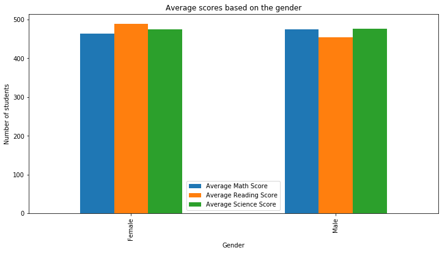

```python
res = df_clean.groupby(['Gender']).mean()[['Average Math Score', 'Average Reading Score', 'Average Science Score']]
ax = res.plot.bar(figsize=(12,6))
plt.ylabel('Number of students')
plt.title('Average scores based on the gender');
```

Again, I want to observe the background of the students.

In my country region (Asia), the concept of parents is often focused on making money. For children, they only pay attention to their achievements but there is no such thing as companionship. However, in the review of modern society, there are more and more suggestions for parents to spend time with their children. Come to help students learn by themselves.

The results of the data we observed below are really proof of this, if at least one of the parents is at home, the score is higher than the child whose parents are not at home.

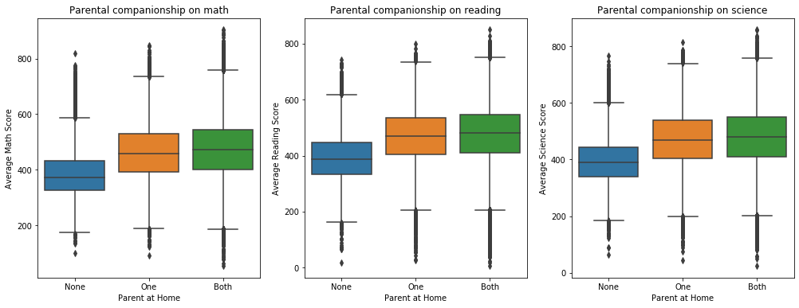

```python
# Sum up Mother at Home and Father at Home 欄位
# 0: Representing parents are not at home
# 1: Representing parents, one at home
# 2: Both parents are at home
df_clean['Parent at Home'] = df_clean['Mother at Home'] + df_clean['Father at Home']
# Convert values to descriptive text
df_clean['Parent at Home'] = df_clean['Parent at Home'].replace({0: 'None', 1: 'One', 2: 'Both'})
plt.figure(figsize = [17, 6])
base_color = sb.color_palette()[0]
order = ['None', 'One', 'Both']
plt.subplot(1, 3, 1)
sb.boxplot(x = df_clean['Parent at Home'], y = df_clean['Average Math Score'], order=order);
plt.title('Parental companionship on math');
plt.subplot(1, 3, 2)
sb.boxplot(x = df_clean['Parent at Home'], y = df_clean['Average Reading Score'], order=order);
plt.title('Parental companionship on reading');
plt.subplot(1, 3, 3)
sb.boxplot(x = df_clean['Parent at Home'], y = df_clean['Average Science Score'], order=order);
plt.title('Parental companionship on science');
```

After reading the individual comparisons, and then from the national data, is the country with the largest population accounting for the majority of the number of applicants? But I am surprised that China, India, and the United States, which have the largest population, do not have the largest number of examinations. Instead, they are Mexico, Italy, Spain, Canaia, whether they are applicants or students. The top four.

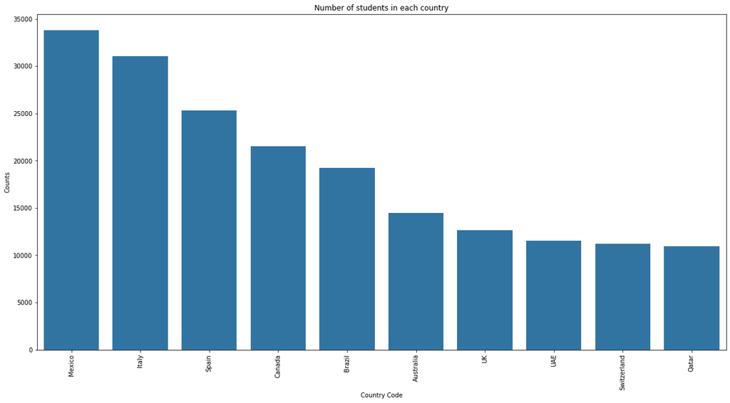

```python
plt.figure(figsize = [20, 10])
base_color = sb.color_palette()[0]
sb.countplot(data = df_clean, x = 'Country Code', color = base_color, order=df_clean['Country Code'].value_counts().index[:10])
plt.title('Number of students in each country')
plt.xticks(rotation='vertical');
plt.ylabel('Counts');
```

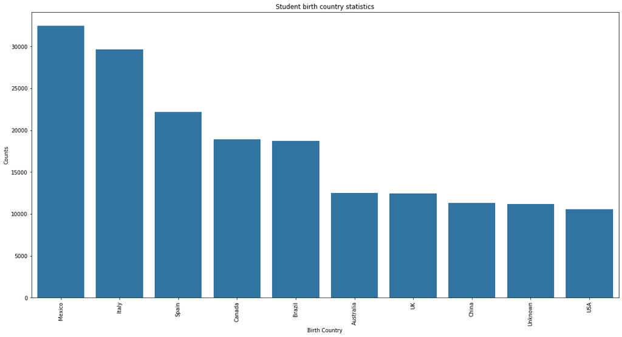

```python
plt.figure(figsize = [20, 10])
base_color = sb.color_palette()[0]
sb.countplot(data = df_clean, x = 'Birth Country', color = base_color, order=df_clean['Birth Country'].value_counts().index[:10])
plt.title('Student birth country statistics')
plt.xticks(rotation='vertical');
plt.ylabel('Counts');
```

Combining the national and student backgrounds, we can ask two questions. The more students' family backgrounds come from, the more knowledge they learn from all aspects (because the strengths of national subjects are generally different)? The following illustration will first calculate the number of household backgrounds from different countries.

- 1: On behalf of students, parents are all in the same country
- 2: Representing students and parents from two countries
- 3: Different countries are born on behalf of students and parents.

```python
# Here, we compute a count which shows the different countries for monter, father, and the student.
# So, 1 means all three are born in the same country
# 2 means two of them are born in different countries
# 3 means all of them are birn in different country
def count_distinct_countries(str):
    s = set()
    for t in str.split(","):
        s.add(t)
    return len(s)

# The three country names of mother, father, and the student are merged to one string for the later process
df_clean['Merged Birth Countries'] = df_clean['Birth Country of Mother'] + "," +  df_clean['Birth Country of Father'] + "," + df_clean['Birth Country'];

# we apply the previously defined function to the merged names of countries to compute the representing number of
# different birth countries
df_clean['Family country combination'] = df_clean['Merged Birth Countries'].apply(count_distinct_countries);
# Convert values to descriptive text
df_clean['Family country combination'] = df_clean['Family country combination'].replace({1: 'Same Country', 2: 'Two Countries', 3:'Different Countries'})
```

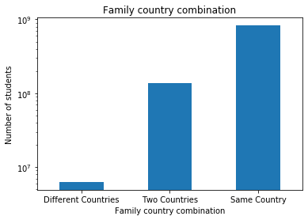

```python
res = df_clean.groupby('Family country combination').sum()['Birth Year'].sort_values()
res.plot.bar(logy=True)
plt.title('Family country combination')
plt.ylabel('Number of students');
plt.xticks(rotation='horizontal');
```

The number of households from different countries, we can't see any difference from the picture below.

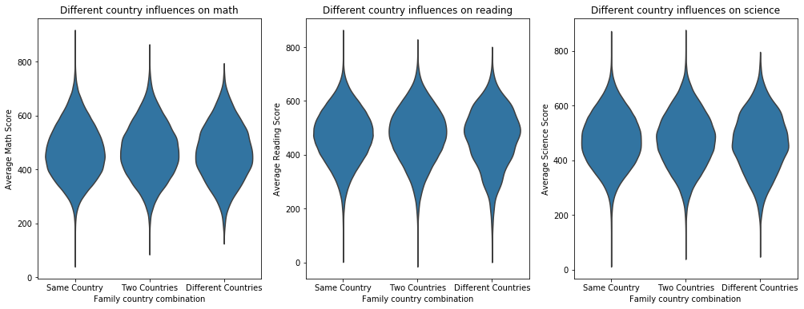

```python
plt.figure(figsize = [17, 6])
base_color = sb.color_palette()[0]
plt.subplot(1, 3, 1)
sb.violinplot(data = df_clean, x = 'Family country combination', y = 'Average Math Score', color = base_color, inner = None)
plt.title('Different country influences on math');
plt.subplot(1, 3, 2)
sb.violinplot(data = df_clean, x = 'Family country combination', y = 'Average Reading Score', color = base_color, inner = None)
plt.title('Different country influences on reading');
plt.subplot(1, 3, 3)
sb.violinplot(data = df_clean, x = 'Family country combination', y = 'Average Science Score', color = base_color, inner = None);
plt.title('Different country influences on science');
```

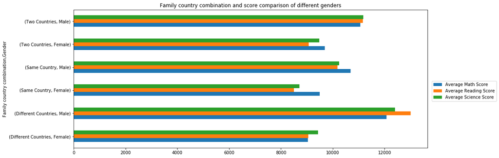

```python
plt.figure(figsize = [50, 20])
res = df_clean.groupby(['Family country combination','Gender']).var()[['Average Math Score', 'Average Reading Score', 'Average Science Score']]
ax = res.plot.barh(figsize=(15,6));
ax.legend(bbox_to_anchor=(1.2, 0.5));
plt.title('Family country combination and score comparison of different genders');
plt.xticks(rotation='horizontal');
```

In general, students' learning is closely related to each subject. From the following correlation diagram, it can be seen that there is a high positive correlation between different subjects.

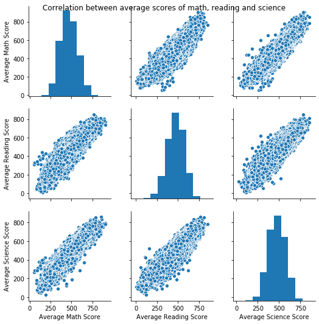

```python
pair_plot = sb.pairplot(data = df_clean, vars=["Average Math Score", "Average Reading Score", "Average Science Score"]);
pair_plot.fig.suptitle("Correlation between average scores of math, reading and science");
```

Finally, we observe the distribution of different scores according to different countries. It can be seen which countries are the strengths of which countries, and the results are as follows:

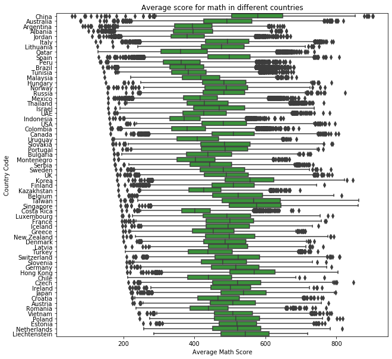

```python
plt.figure(figsize = [10, 10])
df_sorted = df_clean.sort_values(by='Average Math Score')
sb.boxplot(x = df_sorted['Average Math Score'], y = df_sorted['Country Code'], color=sb.color_palette()[2]);
plt.title('Average score for math in different countries');
```

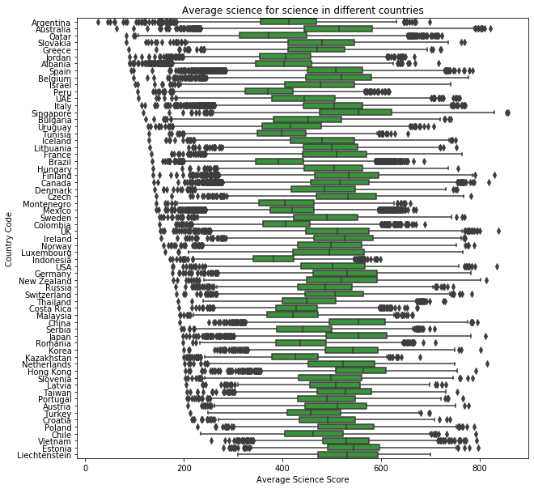

```python
plt.figure(figsize = [10, 10])
df_sorted = df_clean.sort_values(by='Average Science Score')
sb.boxplot(x = df_sorted['Average Science Score'], y = df_sorted['Country Code'], color=sb.color_palette()[2]);
plt.title('Average science for science in different countries');
```

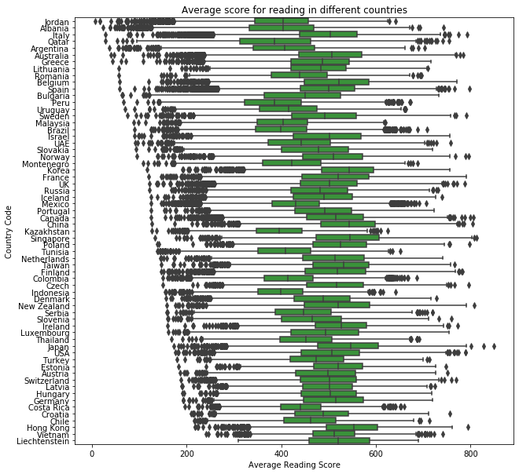

```python
plt.figure(figsize = [10, 10])
df_sorted = df_clean.sort_values(by='Average Reading Score')
sb.boxplot(x = df_sorted['Average Reading Score'], y = df_sorted['Country Code'], color=sb.color_palette()[2]);
plt.title('Average score for reading in different countries');
```

# Conclusions

1. How do students from individual countries perform in Math, Reading and Science literacy?

1. What are the countries from which "geniuses" stem, meaning which countries have students with exceptionally high literacy scores?

Generally, we have seen Asian countries as being the world leaders at educating students who perform exceptionally, not only in each different subject individually, but also at multiple subjects simultaneously. Singapore and China are examples of this.

```python
from subprocess import call
call(['python', '-m', 'nbconvert', 'slide_deck_template.ipynb'])
```

```
0
```